# RTFactivity

**RTFactivity** is an R package to estimate the **Relative Transcription Factor (TF) Activity** between two biological conditions using gene regulatory networks (GRNs) and differentially expressed genes (DEGs). It computes both **direct** and **cascade (indirect)** effects of transcription factors, enabling discovery of key regulators that drive **cell state transitions**, such as those involved in wound healing, cell reprogramming, or regeneration.

## ✨ Key Features

- Calculates **direct TF scores** based on immediate targets
- Calculates **cascade TF scores** through second-order targets (targets-of-targets)
- Compatible with any user-provided GRN (global or cell type–specific)
- Accepts standard DE results (Seurat, DESeq2, edgeR, etc.)
- Designed for applications in **regeneration**, **differentiation**, and **disease modeling**

## 📦 Installation

```r
install.packages("devtools")
devtools::install_github("safwat190/RTFactivity")
```

## 🚀 Quick Start

```r
library(RTFactivity)
library(dplyr)
library(pheatmap)
library(ggplot2)
library(ggrepel)
```

#### Load example data:

- **example_DEGs**: differentially expressed genes in fibroblasts between healing and nonhealing ulcer)
- **example_GRN**: fibroblast gene regulatory network (GRN)

```r
data("example_DEGs")
data("example_GRN")

# convert GRN to gene sets
geneset_GRN <- split(example_GRN$Target, example_GRN$TF)

# order DEGs in descending order
example_DEGs <- example_DEGs[order(-example_DEGs$avg_log2FC), ]

# prepare ranked gene list from DEGs
ranked_list = example_DEGs$avg_log2FC
names(ranked_list) = example_DEGs$gene
ranked_list <- sort(ranked_list, decreasing = TRUE)
```

#### Check the number of target genes regulated by each transcription factor that are differentially expressed

```r
tf_summary <- count_targets(geneset_GRN, deg_genes = example_DEGs$gene)
head(tf_summary)
hist(tf_summary$n_targets, breaks = 30)
hist(tf_summary$n_targets_in_DEGs, breaks = 30)
plot(tf_summary$n_targets, tf_summary$n_targets_in_DEGs)
summary(tf_summary$n_targets_in_DEGs)
```

#### Calculate the relative activity of each TF in fibroblasts between healing and non-healing DFU

```r
gsea_res_GRN = calculate_relative_score(geneset_GRN = geneset_GRN,
                                        ranked_list = ranked_list,
                                        minSize = 10,
                                        maxSize = 1000)
View(gsea_res_GRN)
# Get TFs with adjusted p value < 0.05
gsea_res_GRN_sig = subset(gsea_res_GRN, subset = padj < 0.05)

sig_TFs <- gsea_res_GRN %>%
  filter(padj < 0.05) %>%
  arrange(desc(NES)) %>%
  pull(pathway)
```

#### Plot heatmap for top 5 with positive and negative scores

[figure not shown]

```r
# get TF names
top_TF = 5
sig_TFs = c(head(sig_TFs,top_TF),tail(sig_TFs,top_TF))

# Create a dataframe to store their targets among DEGs as binaries
targets_df <- data.frame(row.names = example_DEGs$gene)

for (tf in sig_TFs) {
  targets_df[[tf]] <- ifelse(rownames(targets_df) %in% geneset_GRN[[tf]], 1, 0)
}
head(targets_df)
tail(targets_df)

# annotate upregulated and downregulated genes in the heatmap
annotation_row <- data.frame(
  direction = ifelse(example_DEGs$avg_log2FC > 0, "positive", "negative")
)
rownames(annotation_row) <- example_DEGs$gene

pheatmap(targets_df,
         cluster_rows = F,
         cluster_cols = F,
         color = colorRampPalette(c("white", "firebrick3"))(50),
         angle_col = 90,
         annotation_row = annotation_row,
         na_col = "grey90",
         border_color = 'white',
         show_rownames = FALSE
)
```

#### Calculate indirect scores based on targets of targets

```r
adjusted_scores <- adjust_scores_target_average(
  gsea_res = setNames(gsea_res_GRN_sig$NES, gsea_res_GRN_sig$pathway),
  geneset_GRN = geneset_GRN,
  alpha = 0.5
)

# View results
head(adjusted_scores)
```

#### Plot direct against indirect scores

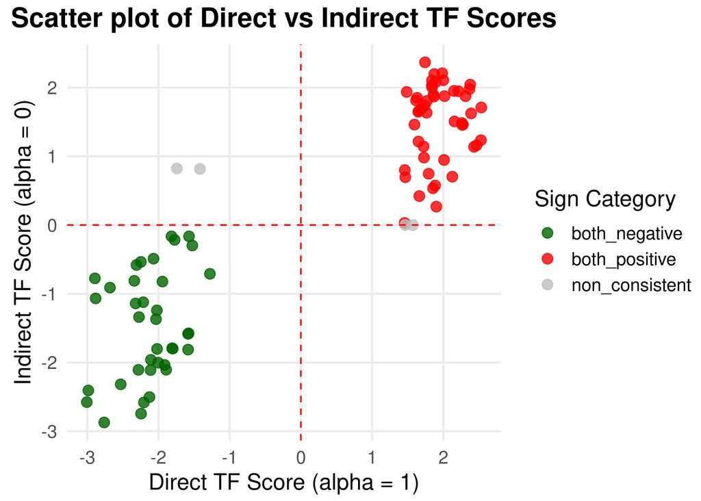

```r
adjusted_scores$sign_category <- with(adjusted_scores, ifelse(
  direct.alpha.1 > 0 & indirect.alpha.0 > 0, "both_positive",
  ifelse(direct.alpha.1 < 0 & indirect.alpha.0 < 0, "both_negative", "non_consistent")
))

ggplot(adjusted_scores, aes(x = direct.alpha.1, y = indirect.alpha.0, color = sign_category)) +
  geom_point(size = 3, alpha = 0.8) +
  geom_hline(yintercept = 0, linetype = "dashed", color = "red") +
  geom_vline(xintercept = 0, linetype = "dashed", color = "red") +
  scale_color_manual(
    values = c(
      both_positive = "red",
      both_negative = "darkgreen",
      non_consistent = "grey"
    )
  ) +
  labs(
    title = "Scatter plot of Direct vs Indirect TF Scores",
    x = "Direct TF Score (alpha = 1)",
    y = "Indirect TF Score (alpha = 0)",
    color = "Sign Category",
  ) +
  theme_minimal(base_size = 15) +
  theme(
    plot.title = element_text(face = "bold", hjust = 0.5),
    axis.title = element_text(),
    panel.grid.minor = element_blank()
  )
```

#### Show TF names on the plot

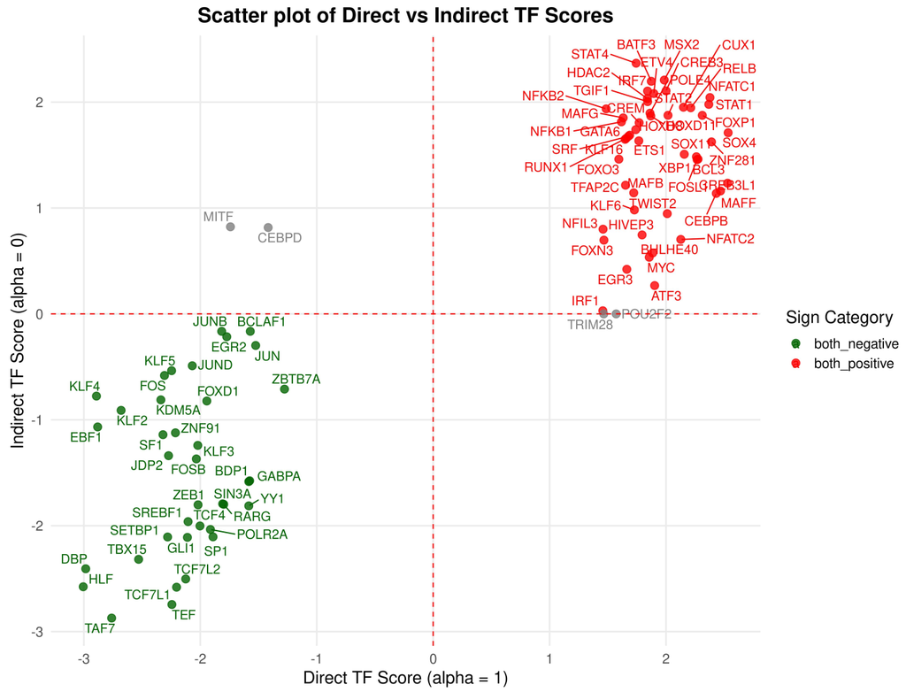

```r
ggplot(adjusted_scores, aes(x = direct.alpha.1, y = indirect.alpha.0, color = sign_category)) +
  geom_point(size = 3, alpha = 0.8) +
  geom_text_repel(aes(label = TF), size = 4, max.overlaps = Inf) +
  geom_hline(yintercept = 0, linetype = "dashed", color = "red") +
  geom_vline(xintercept = 0, linetype = "dashed", color = "red") +
  scale_color_manual(
    values = c(
      both_positive = "red",
      both_negative = "darkgreen",
      mixed = "grey"
    )
  ) +
  labs(
    title = "Scatter plot of Direct vs Indirect TF Scores",
    x = "Direct TF Score (alpha = 1)",
    y = "Indirect TF Score (alpha = 0)",
    color = "Sign Category",
  ) +
  theme_minimal(base_size = 15) +
  theme(
    plot.title = element_text(face = "bold", hjust = 0.5),
    axis.title = element_text(),
    panel.grid.minor = element_blank()
  )
```

#### Get direct downstream targets for the TF NR3C1

```r
res <- get_downstream("NR3C1", geneset_GRN, max_depth = 1, exclude_self = T)
res$edges
res$downstream_targets
```

#### Get indirect downstream targets for the TF NR3C1 at 2 levels

```r
res <- get_downstream("NR3C1", geneset_GRN, max_depth = 2, exclude_self = T)
res$edges
res$downstream_targets
```

#### Get direct upstream targets for the TF NR3C1

```r
res <- get_upstream("NR3C1", geneset_GRN, max_depth = 1, exclude_self = T)
res$edges
res$upstream_TFs
```

#### Get indirect upstream targets for the TF NR3C1 at 2 levels

```r
res <- get_upstream("NR3C1", geneset_GRN, max_depth = 2, exclude_self = T)
res$edges
res$upstream_TFs
```

## 📂 Input Format

Your input should include:

```
DEGs table (data frame):
    - gene: gene symbol
    - logFC: log fold-change between condition A vs B
    - adj.pval: adjusted p-value

Gene Regulatory Network (GRN) (data frame):
    - TF: transcription factor name
    - Target: gene regulated by TF
```

## 📈 Output

- **TF**: transcription factor name
- **direct.alpha.1**: TF score based on direct targets only
- **indirect.alpha.0**: TF score based on indirect targets only
- **combined.alpha.of.interest**: weighted average TF score based on alpha (between 0 and 1)

## 🌍 Applications

RTFactivity was developed to identify TFs driving beneficial cell state transitions such as in:

```
✅ Wound healing (e.g., reprogramming fibroblasts to promote angiogenesis)

✅ Beta cell differentiation

✅ Spinal cord regeneration
```

## 📚 Citation

Ahmed S. Abouhashem, et al. (2025). Identification of Skin Multicellular Reprogramming Factors as Potential Treatment for Non-Healing Diabetic Foot Ulcers. [Under Revision] RTFactivity GitHub: https://github.com/safwat190/RTFactivity

**If you use scoring function “calculate_relative_score” which is the same as “fgsea” from the package fgsea, please cite the package original papers:**

- Korotkevich G, Sukhov V, Sergushichev A (2019). “Fast gene set enrichment analysis.” bioRxiv. doi:10.1101/060012
- Subramanian, A., Tamayo, P., Mootha, V. K., Mukherjee, S., Ebert, B. L., Gillette, M. A., Paulovich, A., Pomeroy, S. L., Golub, T. R., Lander, E. S., & Mesirov, J. P. (2005). Gene set enrichment analysis: a knowledge-based approach for interpreting genome-wide expression profiles. Proceedings of the National Academy of Sciences of the United States of America, 102(43), 15545–15550. https://doi.org/10.1073/pnas.0506580102

## 🤝 Contributing

Pull requests and feedback are welcome. Please open an issue or submit changes via PR.

## 🧠 Maintainer

Dr. Ahmed S. Abouhashem  
Research Assistant Professor  
University of Pittsburgh  
📧 A.S.A@pitt.edu